# Introduction to Pharmacogenomics Tools

The main purpose of this hands on activity is to familiarize the participant with the different packages available to download, preprocess and visualize pharmacogenomics data. In particular, we will be focusing on two R packages, `PharmacoGx` 1 and `GRmetrics`, and giving a brief overview of the `GDSCTools` python package.

# PharmacoGx

*PharmacoGx* was developed to serve as a platform for integrating analysis across different datasets. The main focus of the `r BiocStyle::Biocpkg("PharmacoGx")` package is to provide access to pharmacogenomics datasets that have been preprocessed with a uniform pipeline, and extensively curated to ensure maximum overlap and consistency. For this purpose, PharmacoGx introduces new data structure, called a for storing pharmacogenomics studies, based on a level of abstraction from the raw experimental data, and allows bioinformaticians and biologists to work with data at the level of genes, drugs and cell lines. This provides a more intuitive interface and, in combination with unified curation, simplifies analyses between multiple datasets. The purpose of this section is to familiarize the reader with the data structures and utilites provided by PharamcoGx, to most quickly access pharmacogenomics data of interest.

*PharmacoGx* is available from the Bioconductor project. To install *PharmacoGx*, we use the `r BiocStyle::CRANpkg("BiocManager")` library:

```r
library(BiocManager)
library(Biobase)
require(PharmacoGx) || install("PharmacoGx")
```

Load *PharmacoGx* into your current workspace:

```r
suppressPackageStartupMessages({
  library(PharmacoGx, verbose=FALSE)
  library(Biobase, verbose=FALSE)
})
```

## Overview of PharmacoGx Functionality

### Downloading PharmacoSet objects

We have made the PharmacoSet objects of the curated datasets available for download using functions provided in the package. A table of available PharmacoSet objects can be obtained by using the *availablePSets* function. Any of the PharmacoSets in the table can then be downloaded by calling *downloadPSet*, which saves the datasets into a directory of the users choice, and returns the data into the R session.

```r
  availablePSets(saveDir=file.path(".", "Safikhani_Pharmacogenomics"))
  GDSC <- downloadPSet("GDSC", saveDir=file.path(".", "PSets"))
  CCLE <- downloadPSet("CCLE", saveDir=file.path(".", "PSets"))
```

## Reproducibility

*PharmacoGx* can be used to process pharmacogenomic datasets. First we want to check the heterogenity of cell lines in one of the available psets, CCLE.

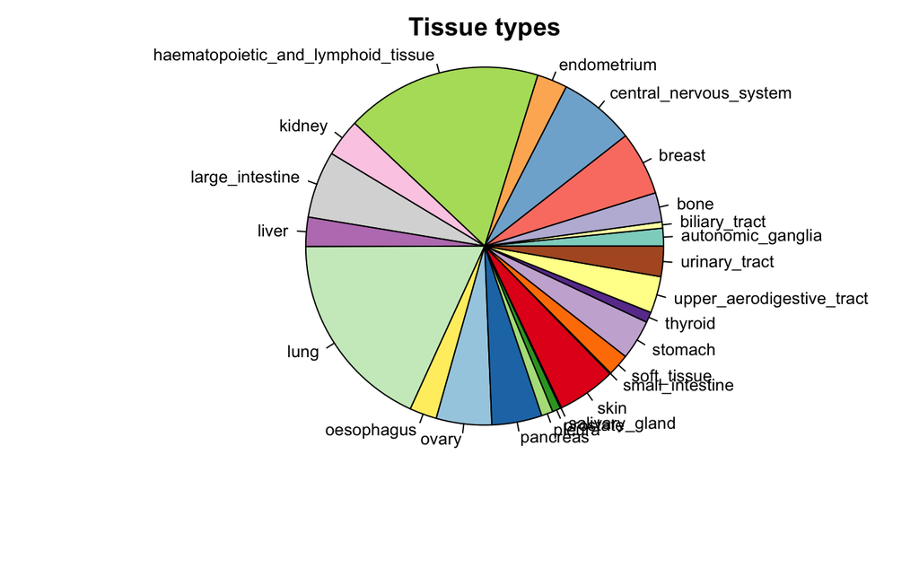

```r
mycol <- c("#8dd3c7","#ffffb3","#bebada","#fb8072","#80b1d3","#fdb462",
           "#b3de69","#fccde5","#d9d9d9","#bc80bd","#ccebc5","#ffed6f",
           "#a6cee3","#1f78b4","#b2df8a","#33a02c","#fb9a99","#e31a1c",
           "#fdbf6f","#ff7f00","#cab2d6","#6a3d9a","#ffff99","#b15928")
pie(table(CCLE@cell[,"tissueid"]),
    col=mycol,
    main="Tissue types",
    radius=1,
    cex=0.8)
```

### Plotting Drug-Dose Response Data

Drug-Dose response data included in the PharmacoSet objects can be conviniently plotted using the *drugDoseResponseCurve* function. Given a list of PharmacoSets, a drug name and a cell name, it will plot the drug dose response curves for the given cell-drug combination in each dataset, allowing direct comparisons of data between datasets.

```r
CCLE.auc <- summarizeSensitivityProfiles(
                pSet=CCLE,
                sensitivity.measure="auc_published",
                summary.stat="median",
                verbose=FALSE)
lapatinib.aac <- CCLE.auc["lapatinib",]
cells <- names(lapatinib.aac)[
                c(which.min(lapatinib.aac),
                  which((lapatinib.aac > 0.2) & (lapatinib.aac < 0.4))[1],
                  which.max(lapatinib.aac))]
par(mfrow=c(2, 2))
drugDoseResponseCurve(drug="lapatinib", cellline=cells[1],
                      pSets=CCLE, plot.type="Fitted",
                      legends.label="auc_published")
drugDoseResponseCurve(drug="lapatinib", cellline=cells[2],
                      pSets=CCLE, plot.type="Fitted",
                      legends.label="auc_published")
```

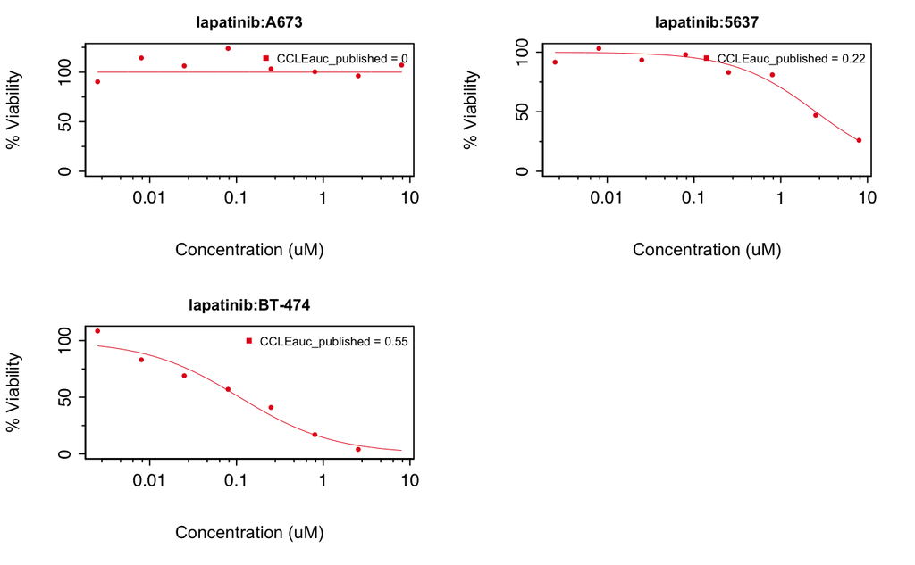

```r
drugDoseResponseCurve(drug="lapatinib", cellline=cells[3],
                      pSets=CCLE, plot.type="Fitted",
                      legends.label="auc_published")
```

### Pharmacological profiles

In pharmacogenomic studies, cancer cell lines were also tested for their response to increasing concentrations of various compounds, and form this the IC50 and AAC were computed. These pharmacological profiles are available for all the psets in *PharmacoGx*.

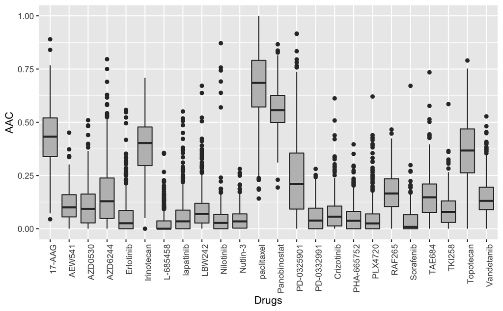

```r
library(ggplot2, verbose=FALSE)
library(reshape2, verbose=FALSE)
melted_data <- melt(CCLE.auc)
NA_rows <- unique(which(is.na(melted_data), arr.ind=T)[,1])
melted_data <- melted_data[-NA_rows,]
ggplot(melted_data, aes(x=Var1,y=value)) +
  geom_boxplot(fill="gray") +
  theme(axis.text.x=element_text(angle=90,hjust=1)) +
  xlab("Drugs") +
  ylab("AAC")
```

```r
#hist(CCLE.auc["lapatinib",], xlab="Cells response to lapatinib(AAC)",
#     col="gray", main="")
```

## Replication

In this section we will investigate the consistency between the GDSC and CCLE datasets. In both CCLE and GDSC, the transcriptome of cells was profiled using an Affymatrix microarray chip. Cells were also tested for their response to increasing concentrations of various compounds, and form this the IC50 and AUC were computed. However, the cell and drugs names used between the two datasets were not consistent. Furthermore, two different microarray platforms were used. However, *PharmacoGx* allows us to overcome these differences to do a comparative study between these two datasets.

GDSC was profiled using the hgu133a platform, while CCLE was profiled with the expanded hgu133plus2 platform. While in this case the hgu133a is almost a strict subset of hgu133plus2 platform, the expression information in *PharmacoSet* objects is summarized by Ensemble Gene Ids, allowing datasets with different platforms to be directly compared. The probe to gene mapping is done using the BrainArray customCDF for each platform .

To begin, you would load the datasets from disk or download them using the *downloadPSet* function above.

We want to investigate the consistency of the data between the two datasets. The common intersection between the datasets can then be found using *intersectPSet*. We create a summary of the gene expression and drug sensitivity measures for both datasets, so we are left with one gene expression profile and one sensitivity profile per cell line within each dataset. We can then compare the gene expression and sensitivity measures between the datasets using a standard correlation coefficient.

```r
common <- intersectPSet(pSets = list("CCLE"=CCLE, "GDSC"=GDSC),
                        intersectOn = c("cell.lines", "drugs"),
                        strictIntersect = TRUE)
```

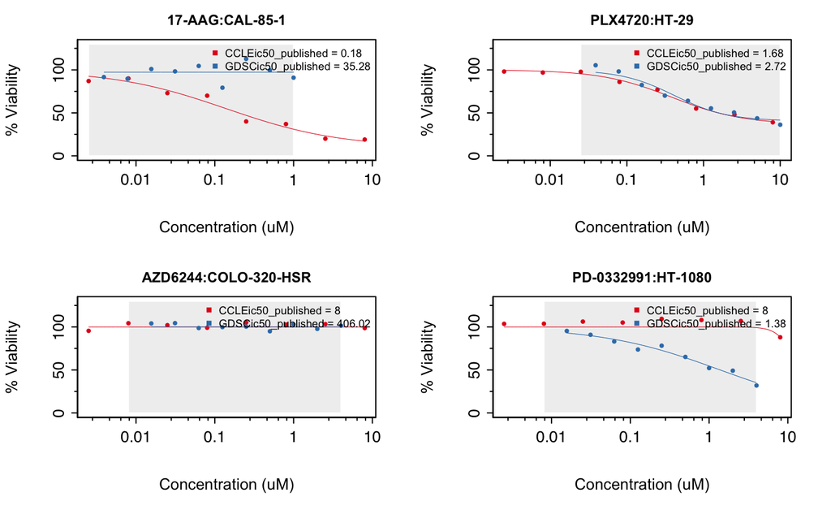

```r
drugs <- drugNames(common$CCLE)
##Example of concordant and discordant drug curves
cases <- rbind(
  c("CAL-85-1", "17-AAG"),
  c("HT-29", "PLX4720"),
  c("COLO-320-HSR", "AZD6244"),
  c("HT-1080", "PD-0332991"))
par(mfrow=c(2, 2))
for (i in seq_len(nrow(cases))) {
  drugDoseResponseCurve(pSets=common,
                        drug=cases[i,2],
                        cellline=cases[i,1],
                        legends.label="ic50_published",
                        plot.type="Fitted",
                        ylim=c(0,130))
}
```

### Consistency of pharmacological profiles

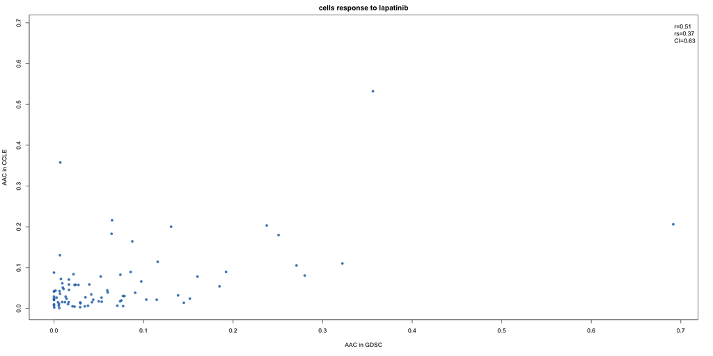

```r
  ##AAC scatter plot
GDSC.aac <- summarizeSensitivityProfiles(
    pSet=common$GDSC,
    sensitivity.measure='auc_recomputed',
    summary.stat="median",
    verbose=FALSE)
CCLE.aac <- summarizeSensitivityProfiles(
  pSet=common$CCLE,
  sensitivity.measure='auc_recomputed',
  summary.stat="median",
  verbose=FALSE)
GDSC.ic50 <- summarizeSensitivityProfiles(
    pSet=common$GDSC,
    sensitivity.measure='ic50_recomputed',
    summary.stat="median",
    verbose=FALSE)
CCLE.ic50 <- summarizeSensitivityProfiles(
  pSet=common$CCLE,
  sensitivity.measure='ic50_recomputed',
  summary.stat="median",
  verbose=FALSE)
drug <- "lapatinib"
#par(mfrow=c(1, 2))
myScatterPlot(x=GDSC.aac[drug,],
              y=CCLE.aac[drug,],
              method=c("transparent"),
              transparency=0.8, pch=16, minp=50,
              xlim=c(0, max(max(GDSC.aac[drug,], na.rm=T), max(CCLE.aac[drug,], na.rm=T))),
              ylim=c(0, max(max(GDSC.aac[drug,], na.rm=T), max(CCLE.aac[drug,], na.rm=T))),
              main="cells response to lapatinib",
              cex.sub=0.7,
              xlab="AAC in GDSC",
              ylab="AAC in CCLE")
legend("topright",
         legend=sprintf("r=%s\nrs=%s\nCI=%s",
                 round(cor(GDSC.aac[drug,],
                           CCLE.aac[drug,],
                           method="pearson",
                           use="pairwise.complete.obs"),
                       digits=2),
                 round(cor(GDSC.aac[drug,],
                           CCLE.aac[drug,],
                           method="spearman",
                           use="pairwise.complete.obs"),
                       digits=2),
                 round(paired.concordance.index(GDSC.aac[drug,],
                                                CCLE.aac[drug,],
                                                delta.pred=0,
                                                delta.obs=0)$cindex,
                       digits=2)),
         bty="n")
```